### One Factor Hull White Model

```python
import numpy as np
import matplotlib.pyplot as plt
import scipy.integrate as integrate
from scipy import interpolate
import scipy.stats as stats
```

# Case Study: Hull-White Model Solution

The Hull-White model [Hull and White, 1990] is a single-factor, no-arbitrage yield curve model in which the short-term interest rate is driven by an extended Ornstein-Uhlenbeck (OU) mean reverting process, given by:

$$ dr(t) = \lambda (\theta(t) − r(t)) dt + \eta dW_r(t), \quad r(0) = r_0 $$

where (\theta(t)) is a time-dependent drift term used to fit the mathematical bond prices to the observed yield curve in the market, and (W_r(t) \equiv W_r^Q(t)) is the Brownian motion under measure (Q).

Parameters:

- (\eta): Determines the overall level of volatility.
- (\lambda): Reversion rate parameter. A large value of (\lambda) causes short-term rate movements to dampen out rapidly, reducing long-term volatility.

## Solution to the SDE

To obtain the solution to SDE, we apply Itô’s lemma to the process (y(t) := e^{\lambda t}r(t)):

$$ dy(t) = \lambda y(t) dt + e^{\lambda t} dr(t) $$

After substitution, we find:

$$ dy(t) = \lambda y(t) dt + e^{\lambda t} \left[\lambda (\theta(t) − r(t)) dt + \eta dW_r(t)\right] $$

This gives us the following system of equations:

$$ \begin{align} y(t) &= e^{\lambda t} r(t) \\ dy(t) &= \lambda \theta(t) e^{\lambda t} dt + \eta e^{\lambda t} dW_r(t) \end{align} $$

The right-hand side of the (y(t))-dynamics does not depend on the state vector (y(t)), allowing us to determine the solution of (y(t)) by integrating both sides of the SDE:

$$ \int_0^t dy(z) = \lambda \int_0^t \theta(z) e^{\lambda z} dz + \eta \int_0^t e^{\lambda z} dW_r(z) $$

Thus,

$$ y(t) = y(0) + \lambda \int_0^t \theta(z) e^{\lambda z} dz + \eta \int_0^t e^{\lambda z} dW_r(z) $$

By the definition of (y(t)), with (y(0) = r_0), the solution for process (r(t)) is:

$$ r(t) = e^{−\lambda t} r_0 + \lambda \int_0^t \theta(z) e^{−\lambda (t−z)} dz + \eta \int_0^t e^{−\lambda (t−z)} dW_r(z) $$

## Distribution of Interest Rate (r(t))

Interest rate (r(t)) is normally distributed with:

$$ E [r(t) | \mathcal{F}(t_0)] = r_0 e^{−\lambda t} + \lambda \int_0^t \theta(z) e^{−\lambda (t−z)} dz, $$

using (t_0 = 0), and

$$ \text{Var}[r(t) | \mathcal{F}(t_0)] = \frac{\eta^2 (1 − e^{−2\lambda t})}{2\lambda} $$

## Special Case: Vašiček Model

Moreover, for (\theta(t)) constant, i.e., (\theta(t) \equiv \theta) (in which case we deal with the Vašiček model [Vašiček, 1977]), we have:

$$ \lim_{t \to \infty} E [r(t) | \mathcal{F}(t_0)] = \theta $$

This means that the first moment of the process converges to the mean reverting level (\theta) for large values of (t).

```python
# Calculate the instantaneous forward rate
def forward_rate(t, ZCB_curve):
    dt = 0.01
    rate = - (np.log(ZCB_curve(t + dt)) - np.log(ZCB_curve(t - dt))) / (2 * dt)
    return rate

# Generate Hull-White model paths using Euler-Maruyama method
def generate_HW_paths(num_paths, num_steps, T, ZCB_curve, lambd, eta):
    r0 = forward_rate(0.01, ZCB_curve)
    dt = T / float(num_steps)
    theta = lambda t: (1.0 / lambd * (forward_rate(t + dt, ZCB_curve) - forward_rate(t - dt, ZCB_curve)) / (2.0 * dt)
                       + forward_rate(t, ZCB_curve) + eta**2 / (2.0 * lambd**2) * (1.0 - np.exp(-2.0 * lambd * t)))

    Z = np.random.normal(0.0, 1.0, [num_paths, num_steps])
    W = np.zeros([num_paths, num_steps + 1])
    R = np.zeros([num_paths, num_steps + 1])
    R[:, 0] = r0
    time = np.zeros([num_steps + 1])

    for i in range(num_steps):
        if num_paths > 1:
            Z[:, i] = (Z[:, i] - np.mean(Z[:, i])) / np.std(Z[:, i])
        W[:, i + 1] = W[:, i] + np.sqrt(dt) * Z[:, i]
        R[:, i + 1] = R[:, i] + lambd * (theta(time[i]) - R[:, i]) * dt + eta * (W[:, i + 1] - W[:, i])
        time[i + 1] = time[i] + dt

    paths = {"time": time, "R": R}
    return paths

# Calculate the theta function for Hull-White model
def HW_theta(lambd, eta, ZCB_curve):
    dt = 0.01
    theta = lambda t: (1.0 / lambd * (forward_rate(t + dt, ZCB_curve) - forward_rate(t - dt, ZCB_curve)) / (2.0 * dt)
                       + forward_rate(t, ZCB_curve) + eta**2 / (2.0 * lambd**2) * (1.0 - np.exp(-2.0 * lambd * t)))
    return theta

# Calculate the A term in the Hull-White model
def HW_A(lambd, eta, ZCB_curve, T1, T2):
    tau = T2 - T1
    zGrid = np.linspace(0.0, tau, 250)
    B_r = lambda tau: 1.0 / lambd * (np.exp(-lambd * tau) - 1.0)
    theta = HW_theta(lambd, eta, ZCB_curve)
    temp1 = lambd * integrate.trapz(theta(T2 - zGrid) * B_r(zGrid), zGrid)
    temp2 = eta**2 / (4.0 * lambd**3) * (np.exp(-2.0 * lambd * tau) * (4 * np.exp(lambd * tau) - 1.0) - 3.0) + eta**2 * tau / (2.0 * lambd**2)
    return temp1 + temp2

# Calculate the B term in the Hull-White model
def HW_B(lambd, T1, T2):
    return 1.0 / lambd * (np.exp(-lambd * (T2 - T1)) - 1.0)

# Calculate the Zero-Coupon Bond price using Hull-White model
def HW_ZCB(lambd, eta, ZCB_curve, T1, T2, rT1):
    B_r = HW_B(lambd, T1, T2)
    A_r = HW_A(lambd, eta, ZCB_curve, T1, T2)
    return np.exp(A_r + B_r * rT1)

# Calculate the initial interest rate using forward rate
def HW_initial_rate(ZCB_curve):
    return forward_rate(0.001, ZCB_curve)
```

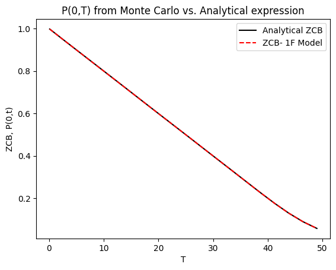

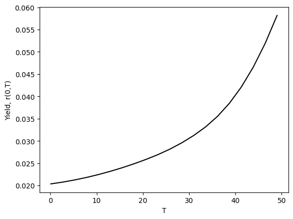

```python
num_paths = 10000
num_steps = 100
lambd = 0.02
eta = 0.002

# Dummy ZCB curve data
time_points = np.linspace(0, 40, 100)
ZCB_prices = np.linspace(1, 0.2, 100)  # Dummy data for ZCB prices

interpolator = interpolate.splrep(time_points, np.log(ZCB_prices), s=0.00001)
ZCB_curve = lambda T: np.exp(interpolate.splev(T, interpolator, der=0))
r0 = HW_initial_rate(ZCB_curve)

# Compare ZCB from the Market and Analytical expression
num_points = 20
T_end = 49.0
T_grid = np.linspace(0.1, T_end, num_points)

exact_ZCB = np.zeros([num_points, 1])
OneFHW = np.zeros([num_points, 1])
yields = np.zeros([num_points, 1])

for i, T in enumerate(T_grid):
    OneFHW[i] = HW_ZCB(lambd, eta, ZCB_curve, 0.0, T, r0)
    exact_ZCB[i] = ZCB_curve(T)
    yields[i] = -np.log(OneFHW[i]) / T

# Plotting
plt.xlabel('T')
plt.ylabel('ZCB, P(0,t)')
plt.plot(T_grid, exact_ZCB, '-k')
plt.plot(T_grid, OneFHW, '--r')
plt.legend(["Analytical ZCB", "ZCB- 1F Model"])
plt.title('P(0,T) from Monte Carlo vs. Analytical expression')
plt.show()

# Yield curve
plt.plot(T_grid, yields, '-k')
plt.xlabel('T')
plt.ylabel('Yield, r(0,T)')
plt.show()
```

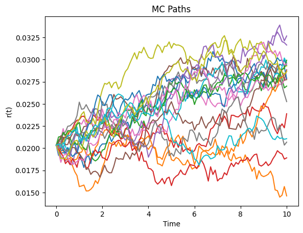

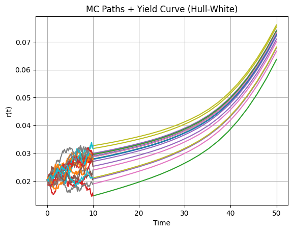

```python
# Monte Carlo part
T_end_MC = 10.0
paths = generate_HW_paths(num_paths, num_steps, T_end_MC, ZCB_curve, lambd, eta)
r = paths["R"]
time_grid = paths["time"]

# Plotting
for i in range(20):
    plt.plot(time_grid, r[i, :])
plt.xlabel('Time')
plt.ylabel('r(t)')
plt.title('MC Paths')
plt.show()

# Yield Curves on the last point
plt.xlabel('Time')
plt.ylabel('r(t)')
plt.title('MC Paths + Yield Curve (Hull-White)')
plt.grid()
T_end_MC2 = T_end_MC + 40.0
T_grid_MC = np.linspace(T_end_MC + 0.001, T_end_MC2 - 0.01, num_points)
ZCB_MC = np.zeros([num_points, 1])
r_T = r[:, -1]

for i in range(20):
    for j, T in enumerate(T_grid_MC):
        ZCB_MC[j] = HW_ZCB(lambd, eta, ZCB_curve, T_end_MC, T, r_T[i])
        yields[j] = -np.log(ZCB_MC[j]) / (T - T_end_MC)
    plt.plot(T_grid_MC, yields)
    plt.plot(time_grid, r[i, :])
plt.show()
```

### Interest Rate Follows Normal Distribution

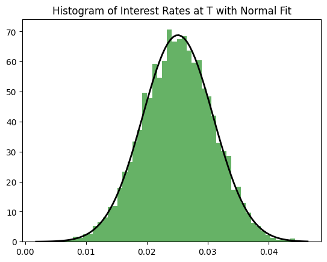

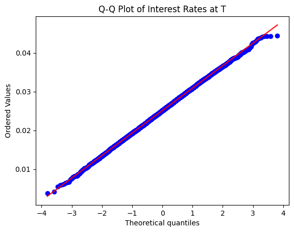

```python
# Check Normal Distribution of Interest Rates
plt.hist(r[:, -1], bins=50, density=True, alpha=0.6, color='g')
mu, std = stats.norm.fit(r[:, -1])
xmin, xmax = plt.xlim()
x = np.linspace(xmin, xmax, 100)
p = stats.norm.pdf(x, mu, std)
plt.plot(x, p, 'k', linewidth=2)
plt.title("Histogram of Interest Rates at T with Normal Fit")
plt.show()

stats.probplot(r[:, -1], dist="norm", plot=plt)
plt.title("Q-Q Plot of Interest Rates at T")
plt.show()
```

### Limitations and Characteristics of the Hull-White Model

#### 1. Yield Curve vs. Forward Curve Fitting

- **Issue**: Can fit the yield curve but not the entire forward curve.
- **Explanation**: The Hull-White model can adjust to the current yield curve using two parameters ((\lambda) and (\eta)), but it cannot perfectly fit the forward curve due to its richer structure involving future rate dynamics.

#### 2. Limited Volatility Structure Fitting

- **Issue**: Only 2 parameters to fit the whole volatility structure.
- **Explanation**: The model uses (\lambda) and (\eta) to describe interest rate volatility, which is insufficient to capture the complex, time-varying volatility structure of the market.

#### 3. Single Stochastic Factor

- **Issue**: Describes interest rate dynamics with only 1 stochastic factor.
- **Explanation**: Real-world interest rates are influenced by multiple factors. The Hull-White model’s single-factor approach oversimplifies these dynamics.

#### 4. Perfect Correlation of Zero-Coupon Bonds (ZCBs)

- **Issue**: ZCBs at a given point are perfectly correlated.
- **Explanation**: Prices of ZCBs maturing at different times are perfectly correlated through their dependence on the short rate (r(t)). In reality, bond prices with different maturities are influenced by different factors and are not perfectly correlated.

### Calculation of NPV and Duration for a Fixed-Rate Bond using the Hull-White Model

### Assumptions

1. The bond pays a fixed coupon rate annually.
2. The bond has a face value of \$1000.
3. The bond's maturity is 10 years.
4. The annual coupon rate is 5%.
5. The short rate follows the Hull-White model.

### Steps

1. Simulate the short rate paths using the Hull-White model.
2. Calculate the discount factors for each simulated short rate path.
3. Calculate the present value of each cash flow (coupon payments and face value) for each path.
4. Average the present values over all paths to get the NPV.
5. Calculate the duration by weighting each cash flow by the time to payment and dividing by the NPV.

```python
# Calculate the NPV of a fixed-rate bond
def calculate_NPV_and_Duration(num_paths, num_steps, ZCB_curve, lambd, eta, face_value, coupon_rate, maturity):
    # Simulate short rate paths
    T = maturity
    paths = generate_HW_paths(num_paths, num_steps, T, ZCB_curve, lambd, eta)
    r = paths["R"]
    time_grid = paths["time"]

    # Calculate the bond's cash flows
    cash_flows = np.full(maturity, coupon_rate * face_value)
    cash_flows[-1] += face_value

    # Initialize arrays to store present values and durations
    present_values = np.zeros((num_paths, maturity))
    durations = np.zeros((num_paths, maturity))

    # Discount each cash flow for each path
    for t in range(maturity):
        discount_factors = np.exp(-np.cumsum(r[:, :t + 1], axis=1) * (time_grid[1] - time_grid[0]))
        present_values[:, t] = cash_flows[t] * discount_factors[:, -1]
        durations[:, t] = t * present_values[:, t]  # Weight by time to payment

    # Calculate NPV and Duration
    NPV = np.mean(np.sum(present_values, axis=1))
    Duration = np.mean(np.sum(durations, axis=1) / NPV)

    return NPV, Duration
```

```python
num_paths = 20000
num_steps = 100
lambd = 0.01
eta = 0.002
face_value = 1000
coupon_rate = 0.05
maturity = 10

# Dummy ZCB curve data
time_points = np.linspace(0, 40, 100)
ZCB_prices = np.linspace(1, 0.2, 100)  # Dummy data for ZCB prices

interpolator = interpolate.splrep(time_points, np.log(ZCB_prices), s=0.00001)
ZCB_curve = lambda T: np.exp(interpolate.splev(T, interpolator, der=0))

# Calculate NPV and Duration
NPV, Duration = calculate_NPV_and_Duration(num_paths, num_steps, ZCB_curve, lambd, eta, face_value, coupon_rate, maturity)

print(f"Net Present Value (NPV): ${NPV:.2f}")
print(f"Duration: {Duration:.2f} years")
```

```
Net Present Value (NPV): $1474.17
Duration: 7.49 years
```